# Exercise Report: Commute Time & Transportation

Author

Liang Lai, Joe Dainis

# 1 Summary

We analyzed five variables (Height, Weight, Gender, Time, and Transportation), created exploratory figures, and fit a linear regression model with Height as the outcome and Time and Transportation as predictors.

# 2 Introduction

## 2.1 Description of data and data source

Two additional variables were added to the original dataset. The variable `Time` measures the average one-way commute time from home to school in minutes and is numeric. The variable `Transportation` is categorical and indicates the primary mode of transportation used for commuting (walk, bike, car, or bus).

# 3 Methods

## 3.1 Data cleaning

In data cleaning process, we addressed obvious data entry issues (e.g., non-numeric height entries such as “sixty” and implausible values), converted variables to appropriate types, and removed observations with missing or clearly invalid values (e.g., missing weight or extreme outliers). The newly added categorical variable `Transportation` was explicitly treated as a factor with valid levels (walk/bike/car/bus).

## 3.2 Statistical analysis

We first conducted exploratory data analysis using figures, including a boxplot of `Height` by `Transportation` and a scatterplot of `Weight` versus `Time`, to assess distributions and potential relationships. We then fit a simple linear regression model with `Height` as the outcome and the two newly added variables (`Time` and `Transportation`) as predictors.

# 4 Results

## 4.1 Exploratory/Descriptive analysis

Table 1 shows a summary of the data.

| skim_type | skim_variable | n_missing | complete_rate | factor.ordered | factor.n_unique | factor.top_counts | numeric.mean | numeric.sd | numeric.p0 | numeric.p25 | numeric.p50 | numeric.p75 | numeric.p100 | numeric.hist |
| --- | --- | --- | --- | --- | --- | --- | --- | --- | --- | --- | --- | --- | --- | --- |
| factor | Gender | 0 | 1 | FALSE | 3 | M: 4, F: 3, O: 2 | NA | NA | NA | NA | NA | NA | NA | NA |
| factor | Transportation | 0 | 1 | FALSE | 4 | car: 3, bik: 2, bus: 2, wal: 2 | NA | NA | NA | NA | NA | NA | NA | NA |
| numeric | Height | 0 | 1 | NA | NA | NA | 165.66667 | 15.97655 | 133 | 156 | 166 | 178 | 183 | ▂▁▃▃▇ |
| numeric | Weight | 0 | 1 | NA | NA | NA | 70.11111 | 21.24526 | 45 | 55 | 70 | 80 | 110 | ▇▂▃▂▂ |
| numeric | Time | 0 | 1 | NA | NA | NA | 21.33333 | 11.15796 | 5 | 15 | 22 | 28 | 40 | ▅▂▇▅▂ |

## 4.2 Basic statistical analysis

We created two exploratory figures to describe the newly added variables and their relationships with other measures. First, we used a boxplot to compare the distribution of `Height` across commuting modes (`Transportation`). Second, we used a scatterplot to visualize the relationship between `Weight` and commute time (`Time`). Figure 1 show a boxplot figure. Figure 2 shows a scatterplot figure.

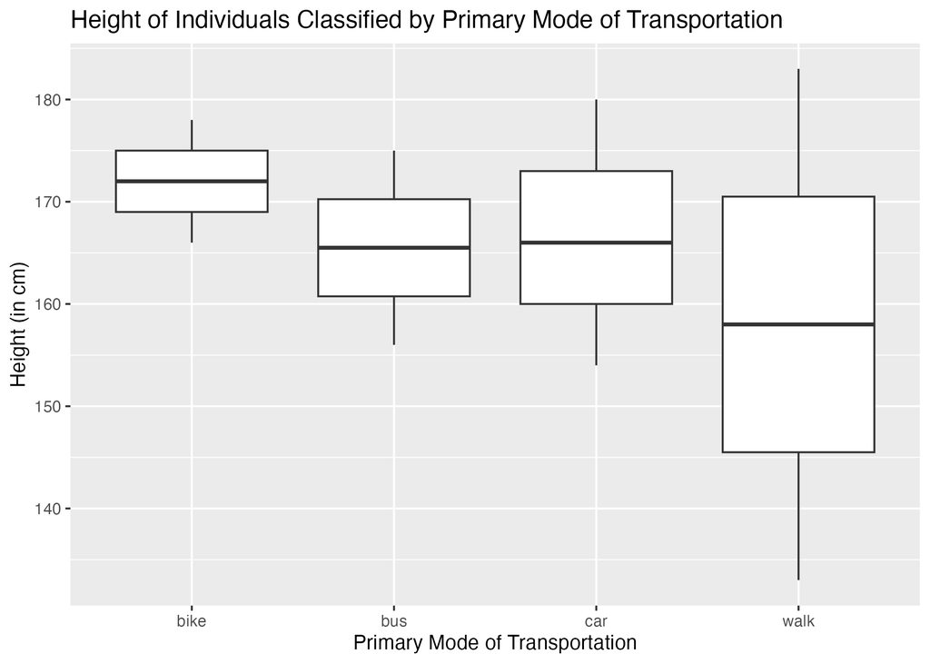

Figure 1: Distribution of height by commuting mode (Transportation).

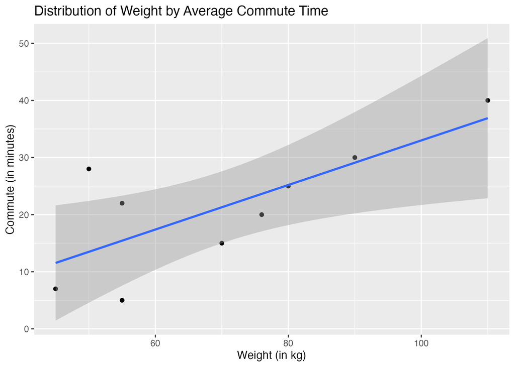

Figure 2: Scatterplot of weight vs commute time (Time).

## 4.3 Full analysis

We fit a linear regression model with Height as the outcome and the two newly added variables (Time and Transportation) as predictors. The model results are shown in Table 2.

Table 2: Linear regression results: Height modeled as a function of Time and Transportation.

| term | estimate | std.error | statistic | p.value |
| --- | --- | --- | --- | --- |
| (Intercept) | 193.865979 | 30.245959 | 6.4096490 | 0.0030439 |
| Time | -1.041237 | 1.275565 | -0.8162948 | 0.4601537 |
| Transportationbus | -4.938144 | 19.955562 | -0.2474570 | 0.8167374 |
| Transportationcar | 5.079038 | 22.170016 | 0.2290949 | 0.8300320 |
| Transportationwalk | -29.618557 | 27.579947 | -1.0739164 | 0.3433272 |

# 5 Discussion

These results show that there are not a statistically meaningful relationship between height and commute time or transportation mode.